# Primeros contrastes de hipótesis

Métodos de contraste de hipótesis y diseño de experimentos

Julio David Ruiz Mendoza

Mayo 2021

## Tarea 1

A unos pacientes se les ha administrado unos medicamentos para ver si son efectivos en la disminución de ciertas moléculas en sangre. Se han tomado medidas al inicio del estudio, a los 3 meses y a los 6 meses. Los valores obtenidos están recogidos en el fichero medicamentos.csv. Se pide: `#Carga la base de datos primero` `#Comprueba que los datos están bien cargados`

```r
medic <- read.csv(file="medicamentos.csv", header = T, stringsAsFactors = T)
head(medic)
```

```
##   ID Sex Group    Month0    Month3   Month6
## 1  1   F     P 12.741917 10.302912 8.302369
## 2  2   F     P  8.870604  8.831782 7.822960
## 3  3   F     P 10.726257 10.737613 9.031419
## 4  4   F     P 11.265725 10.589309 9.327378
## 5  5   F     P 10.808537  1.441481 9.693284
## 6  6   F     P  9.787751  7.327527 9.513506
```

```r
tail(medic)
```

```
##     ID Sex Group    Month0    Month3   Month6
## 91 109   M    M1 10.376386  1.773600 3.723263
## 92 110   M    M1 10.238322  6.547391 6.599292
## 93 111   M    M1  9.949815  4.624806 7.981887
## 94 112   M    M1 10.216145  6.892082 5.083733
## 95 113   M    M1  9.029130  4.375231 9.389059
## 96 114   M    M1  8.991566 10.424111 3.077329
```

1. Contrastar, con nivel de significación α = 0.05, si la media de los valores en el mes inicial (Month0) es 10.

Hipótesis nula: $H_0: \mu = 10$  
Hipótesis alternativa $H_1: \mu \ne 10$

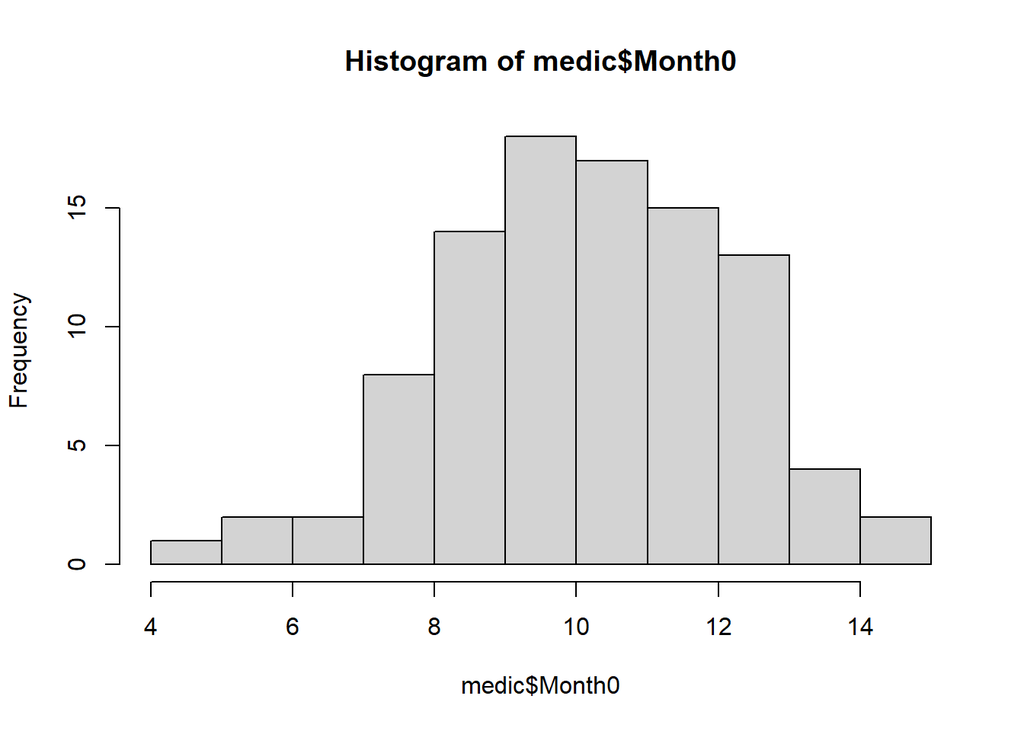

```r
hist( medic$Month0 )
```

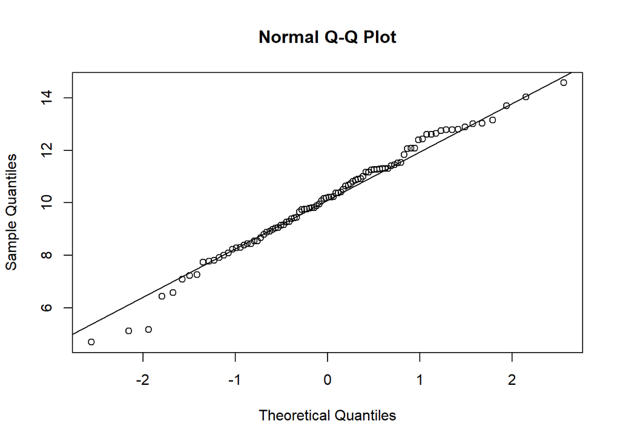

```r
qqnorm( medic$Month0 )
qqline( medic$Month0 )
```

La linea se ajusta.

```r
shapiro.test( medic$Month0 )
```

```
##
##  Shapiro-Wilk normality test
##
## data:  medic$Month0
## W = 0.98767, p-value = 0.5142
```

Tenemos p-valor = 0.5142 > 0.05 en Shapiro-Wilk test.

```r
t.test( medic$Month0, mu = 10, alternative = "two.sided" )
```

```
##
##  One Sample t-test
##
## data:  medic$Month0
## t = 0.63124, df = 95, p-value = 0.5294
## alternative hypothesis: true mean is not equal to 10
## 95 percent confidence interval:
##   9.724152 10.533047
## sample estimates:
## mean of x
##   10.1286
```

Con un p-value = 0.5294 mayor de 0.05 no podemos rechazar la hipótesis nula $H_0$, la diferencia no es estadísticamente significativa. El intervalo de confianza incluye el 10 (9.724152, 10.533047).

2. ¿Debemos aceptar o rechazar la diferencia de la media del mes inicial (Month0) según el sexo (Sex), para α = 0.05?

En principio vamos a suponer las variables **independientes**.

```r
table( medic$Sex ) #n>>
```

```
##
##  F  M
## 48 48
```

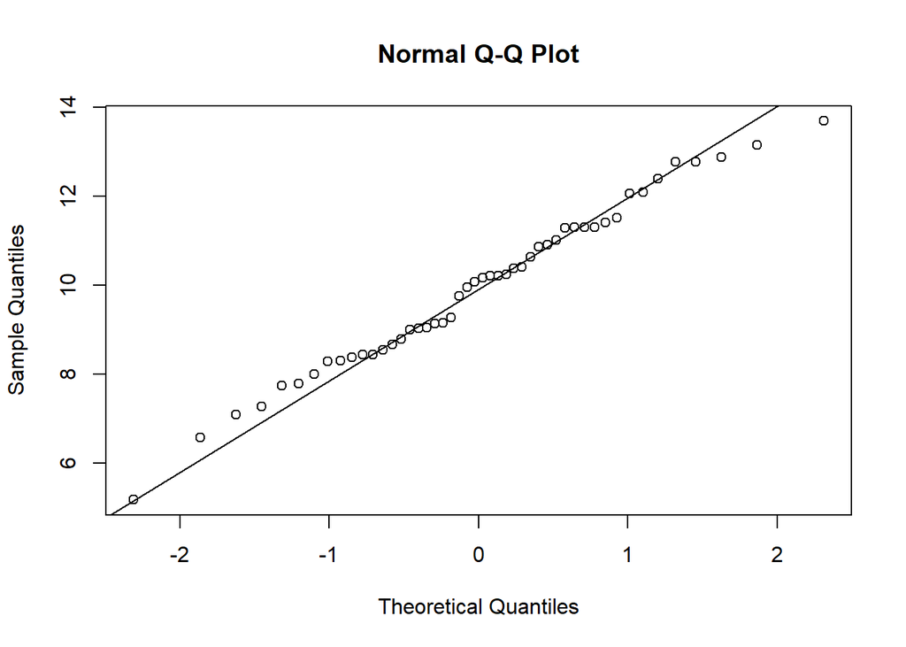

```
##
##  Shapiro-Wilk normality test
##
## data:  M0
## W = 0.98733, p-value = 0.8789
```

```r
M0 <- medic$Month0[medic$Sex == "M"]
F0 <- medic$Month0[medic$Sex == "F"]

qqnorm(M0); qqline(M0); shapiro.test(M0)    #p-value = 0.8789
```

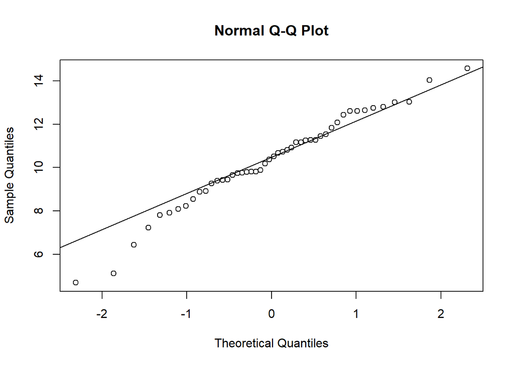

```
##
##  Shapiro-Wilk normality test
##
## data:  F0
## W = 0.97567, p-value = 0.4135
```

```r
qqnorm(F0); qqline(F0); shapiro.test(F0)    #p-value = 0.4135
```

No podemos rechazar la normalidad.

```r
fligner.test( medic$Month0, medic$Sex )
```

```
##
##  Fligner-Killeen test of homogeneity of variances
##
## data:  medic$Month0 and medic$Sex
## Fligner-Killeen:med chi-squared = 0.063022, df = 1, p-value = 0.8018
```

p-value = 0.8018, por lo que no rechazamos homogeneidad de varianzas.

Hipótesis nula: $H_0: \mu_1 = \mu_2$  
Hipótesis alternativa $H_1: \mu_1 \ne \mu_2$

Se supone normalidad y homogeneidad de varianzas.

```r
t.test( medic$Month0 ~ medic$Sex, alternative = "two.sided", paired = F, var.equal = T )
```

```
##
##  Two Sample t-test
##
## data:  medic$Month0 by medic$Sex
## t = 0.952, df = 94, p-value = 0.3435
## alternative hypothesis: true difference in means is not equal to 0
## 95 percent confidence interval:
##  -0.4213205  1.1974887
## sample estimates:
## mean in group F mean in group M
##       10.322642        9.934557
```

p-value = 0.3435 > 0.05, por lo que no rechazamos la hipótesis nula y podemos suponer que las medias son iguales para ambos sexos.

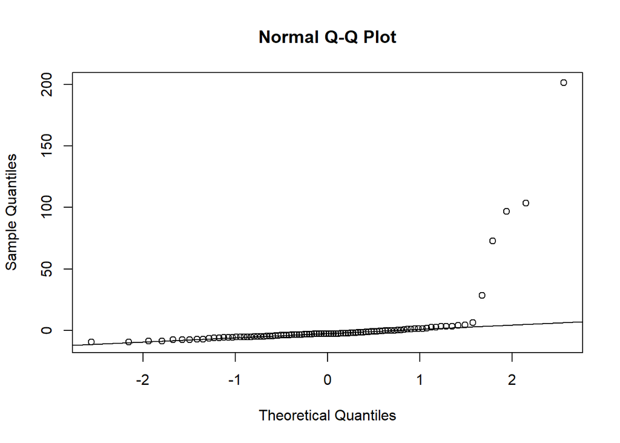

```r
qqnorm( medic$Month3-medic$Month0 ); qqline( medic$Month3-medic$Month0 )
```

```r
shapiro.test( medic$Month3-medic$Month0 )
```

```
##
##  Shapiro-Wilk normality test
##
## data:  medic$Month3 - medic$Month0
## W = 0.31097, p-value < 2.2e-16
```

p-value < 2.2e-16 menor que 0.05 no podemos aceptar la normalidad, pero tenemos una muestra de n = 96 > 50.

```r
t.test( medic$Month3, medic$Month0, alternative = "two.sided", paired = TRUE )
```

```
##
##  Paired t-test
##
## data:  medic$Month3 and medic$Month0
## t = 1.0398, df = 95, p-value = 0.3011
## alternative hypothesis: true difference in means is not equal to 0
## 95 percent confidence interval:
##  -2.570407  8.224541
## sample estimates:
## mean of the differences
##                2.827067
```

4. Dentro del grupo “P” (nos quedamos con los datos solo de este grupo), ¿hay diferencias significativas en la media del mes 3 (Month3) con respecto a sexo?

```r
library("dplyr")
medicP <- filter(medic, Group=="P")
table( medicP$Sex )
```

```
##
##  F  M
## 24 24
```

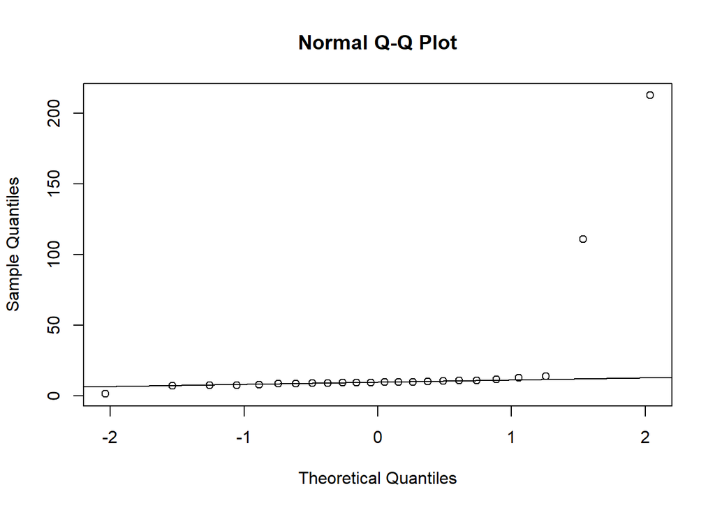

```
##
##  Shapiro-Wilk normality test
##
## data:  MP3
## W = 0.36032, p-value = 3.177e-09
```

```r
MP3 <- medicP$Month3[medicP$Sex == "M"]
FP3 <- medicP$Month3[medicP$Sex == "F"]

qqnorm(MP3); qqline(MP3); shapiro.test(MP3)    #p-value = 3.177e-09
```

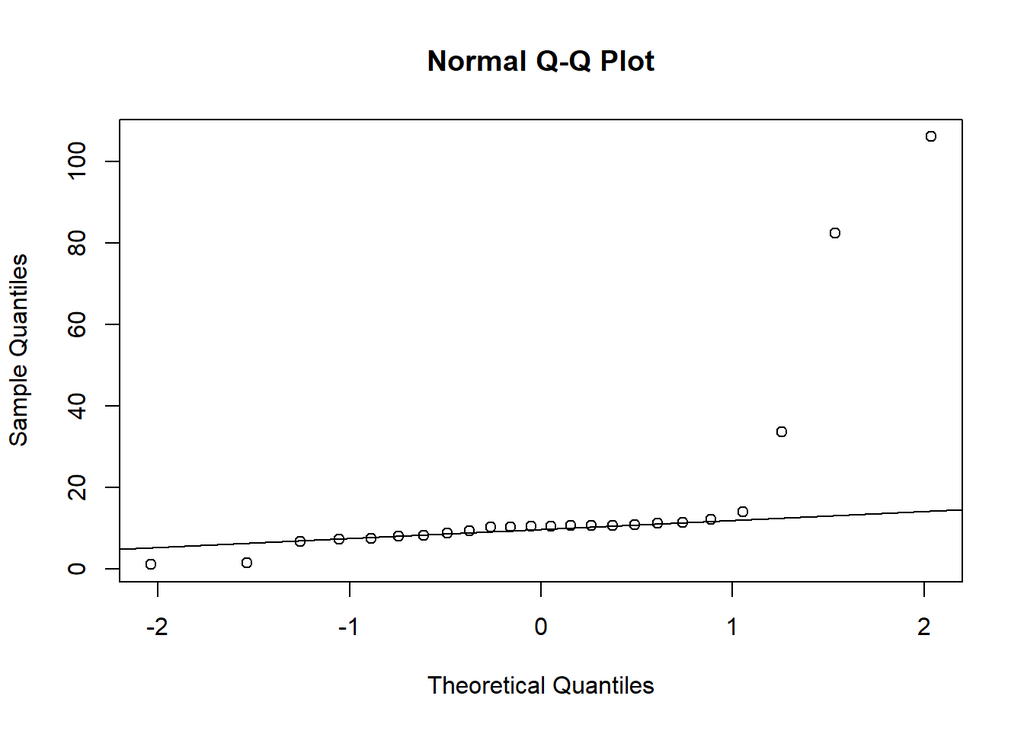

```
##
##  Shapiro-Wilk normality test
##
## data:  FP3
## W = 0.48883, p-value = 4.4e-08
```

```r
qqnorm(FP3); qqline(FP3); shapiro.test(FP3)    #p-value = 4.4e-08
```

No podemos aceptar la suposición de normalidad y la muestra no suficientemente grande (n=24), por lo que el test puede darnos un falso positivo.

```r
fligner.test( medicP$Month0, medicP$Sex )
```

```
##
##  Fligner-Killeen test of homogeneity of variances
##
## data:  medicP$Month0 and medicP$Sex
## Fligner-Killeen:med chi-squared = 0.24071, df = 1, p-value = 0.6237
```

Hipótesis nula: $H_0: \mu_1 = \mu_2$  
Hipótesis alternativa $H_1: \mu_1 \ne \mu_2$ No suponemos normalidad y suponemos homogeneidad de varianzas.

```r
#t.test(medic$Month0 ~ medic$Sex, alternative = "two.sided", paired = F, var.equal = T)
wilcox.test( Month3 ~ Sex, data = medicP )
```

```
##
##  Wilcoxon rank sum exact test
##
## data:  Month3 by Sex
## W = 303, p-value = 0.767
## alternative hypothesis: true location shift is not equal to 0
```

Hemos calculado un p-value = 0.767 > 0.05, no rechazamos $H_0$ por lo que no visualizamos diferencias en la media en el mes 3 respecto al sexo.